# Part I - Prosper Loan Data Exploration

## Introduction

> The Prosper Loan dataset downloaded from the Udacity "Communicate Data Findings Project" dataset options page. It contains 113,937 observations with 81 variables on each loan, including loan amount, borrower rate (or interest rate), current loan status, borrower income, and many others.

## Preliminary Wrangling

```python
# import all packages and set plots to be embedded inline
import numpy as np
import pandas as pd
import matplotlib.pyplot as plt
import seaborn as sb

import warnings
warnings.filterwarnings("ignore")

%matplotlib inline
```

> Load in your dataset and describe its properties through the questions below. Try and motivate your exploration goals through this section.

```python
# Loading the dataset
loan_df = pd.read_csv('prosperLoanData.csv')
loan_df.head()
```

|  | ListingKey | ListingNumber | ListingCreationDate | CreditGrade | Term | LoanStatus | ClosedDate | BorrowerAPR | BorrowerRate | LenderYield | ... | LP_ServiceFees | LP_CollectionFees | LP_GrossPrincipalLoss | LP_NetPrincipalLoss | LP_NonPrincipalRecoverypayments | PercentFunded | Recommendations | InvestmentFromFriendsCount | InvestmentFromFriendsAmount | Investors |
| --- | --- | --- | --- | --- | --- | --- | --- | --- | --- | --- | --- | --- | --- | --- | --- | --- | --- | --- | --- | --- | --- |
| 0 | 1021339766868145413AB3B | 193129 | 2007-08-26 19:09:29.263000000 | C | 36 | Completed | 2009-08-14 00:00:00 | 0.16516 | 0.1580 | 0.1380 | ... | -133.18 | 0.0 | 0.0 | 0.0 | 0.0 | 1.0 | 0 | 0 | 0.0 | 258 |
| 1 | 10273602499503308B223C1 | 1209647 | 2014-02-27 08:28:07.900000000 | NaN | 36 | Current | NaN | 0.12016 | 0.0920 | 0.0820 | ... | 0.00 | 0.0 | 0.0 | 0.0 | 0.0 | 1.0 | 0 | 0 | 0.0 | 1 |
| 2 | 0EE9337825851032864889A | 81716 | 2007-01-05 15:00:47.090000000 | HR | 36 | Completed | 2009-12-17 00:00:00 | 0.28269 | 0.2750 | 0.2400 | ... | -24.20 | 0.0 | 0.0 | 0.0 | 0.0 | 1.0 | 0 | 0 | 0.0 | 41 |
| 3 | 0EF5356002482715299901A | 658116 | 2012-10-22 11:02:35.010000000 | NaN | 36 | Current | NaN | 0.12528 | 0.0974 | 0.0874 | ... | -108.01 | 0.0 | 0.0 | 0.0 | 0.0 | 1.0 | 0 | 0 | 0.0 | 158 |
| 4 | 0F023589499656230C5E3E2 | 909464 | 2013-09-14 18:38:39.097000000 | NaN | 36 | Current | NaN | 0.24614 | 0.2085 | 0.1985 | ... | -60.27 | 0.0 | 0.0 | 0.0 | 0.0 | 1.0 | 0 | 0 | 0.0 | 20 |

5 rows × 81 columns

```python
# Assessing the data types and Null values
loan_df.info()
```

```
<class 'pandas.core.frame.DataFrame'>
RangeIndex: 113937 entries, 0 to 113936
Data columns (total 81 columns):
 #   Column                               Non-Null Count   Dtype
---  ------                               --------------   -----
 0   ListingKey                           113937 non-null  object
 1   ListingNumber                        113937 non-null  int64
 2   ListingCreationDate                  113937 non-null  object
 3   CreditGrade                          28953 non-null   object
 4   Term                                 113937 non-null  int64
 5   LoanStatus                           113937 non-null  object
 6   ClosedDate                           55089 non-null   object
 7   BorrowerAPR                          113912 non-null  float64
 8   BorrowerRate                         113937 non-null  float64
 9   LenderYield                          113937 non-null  float64
```

[output cut: 73 more lines]

```python
# Descriptive statistics on all numeric values in the dataset
loan_df.describe()
```

|  | ListingNumber | Term | BorrowerAPR | BorrowerRate | LenderYield | EstimatedEffectiveYield | EstimatedLoss | EstimatedReturn | ProsperRating (numeric) | ProsperScore | ... | LP_ServiceFees | LP_CollectionFees | LP_GrossPrincipalLoss | LP_NetPrincipalLoss | LP_NonPrincipalRecoverypayments | PercentFunded | Recommendations | InvestmentFromFriendsCount | InvestmentFromFriendsAmount | Investors |
| --- | --- | --- | --- | --- | --- | --- | --- | --- | --- | --- | --- | --- | --- | --- | --- | --- | --- | --- | --- | --- | --- |
| count | 1.139370e+05 | 113937.000000 | 113912.000000 | 113937.000000 | 113937.000000 | 84853.000000 | 84853.000000 | 84853.000000 | 84853.000000 | 84853.000000 | ... | 113937.000000 | 113937.000000 | 113937.000000 | 113937.000000 | 113937.000000 | 113937.000000 | 113937.000000 | 113937.000000 | 113937.000000 | 113937.000000 |
| mean | 6.278857e+05 | 40.830248 | 0.218828 | 0.192764 | 0.182701 | 0.168661 | 0.080306 | 0.096068 | 4.072243 | 5.950067 | ... | -54.725641 | -14.242698 | 700.446342 | 681.420499 | 25.142686 | 0.998584 | 0.048027 | 0.023460 | 16.550751 | 80.475228 |
| std | 3.280762e+05 | 10.436212 | 0.080364 | 0.074818 | 0.074516 | 0.068467 | 0.046764 | 0.030403 | 1.673227 | 2.376501 | ... | 60.675425 | 109.232758 | 2388.513831 | 2357.167068 | 275.657937 | 0.017919 | 0.332353 | 0.232412 | 294.545422 | 103.239020 |
| min | 4.000000e+00 | 12.000000 | 0.006530 | 0.000000 | -0.010000 | -0.182700 | 0.004900 | -0.182700 | 1.000000 | 1.000000 | ... | -664.870000 | -9274.750000 | -94.200000 | -954.550000 | 0.000000 | 0.700000 | 0.000000 | 0.000000 | 0.000000 | 1.000000 |
| 25% | 4.009190e+05 | 36.000000 | 0.156290 | 0.134000 | 0.124200 | 0.115670 | 0.042400 | 0.074080 | 3.000000 | 4.000000 | ... | -73.180000 | 0.000000 | 0.000000 | 0.000000 | 0.000000 | 1.000000 | 0.000000 | 0.000000 | 0.000000 | 2.000000 |
| 50% | 6.005540e+05 | 36.000000 | 0.209760 | 0.184000 | 0.173000 | 0.161500 | 0.072400 | 0.091700 | 4.000000 | 6.000000 | ... | -34.440000 | 0.000000 | 0.000000 | 0.000000 | 0.000000 | 1.000000 | 0.000000 | 0.000000 | 0.000000 | 44.000000 |
| 75% | 8.926340e+05 | 36.000000 | 0.283810 | 0.250000 | 0.240000 | 0.224300 | 0.112000 | 0.116600 | 5.000000 | 8.000000 | ... | -13.920000 | 0.000000 | 0.000000 | 0.000000 | 0.000000 | 1.000000 | 0.000000 | 0.000000 | 0.000000 | 115.000000 |
| max | 1.255725e+06 | 60.000000 | 0.512290 | 0.497500 | 0.492500 | 0.319900 | 0.366000 | 0.283700 | 7.000000 | 11.000000 | ... | 32.060000 | 0.000000 | 25000.000000 | 25000.000000 | 21117.900000 | 1.012500 | 39.000000 | 33.000000 | 25000.000000 | 1189.000000 |

8 rows × 61 columns

```python
# selecting some variables to explore
loan_dfe = loan_df[['LoanStatus', 'LoanOriginalAmount', 'BorrowerRate', 'Occupation', 'EmploymentStatus',
                   'EmploymentStatusDuration', 'IsBorrowerHomeowner', 'CurrentlyInGroup', 'IncomeRange',
                   'CreditScoreRangeLower', 'CreditScoreRangeUpper']]
```

```python
loan_dfe.head()
```

|  | LoanStatus | LoanOriginalAmount | BorrowerRate | Occupation | EmploymentStatus | EmploymentStatusDuration | IsBorrowerHomeowner | CurrentlyInGroup | IncomeRange | CreditScoreRangeLower | CreditScoreRangeUpper |
| --- | --- | --- | --- | --- | --- | --- | --- | --- | --- | --- | --- |
| 0 | Completed | 9425 | 0.1580 | Other | Self-employed | 2.0 | True | True | $25,000-49,999 | 640.0 | 659.0 |
| 1 | Current | 10000 | 0.0920 | Professional | Employed | 44.0 | False | False | $50,000-74,999 | 680.0 | 699.0 |
| 2 | Completed | 3001 | 0.2750 | Other | Not available | NaN | False | True | Not displayed | 480.0 | 499.0 |
| 3 | Current | 10000 | 0.0974 | Skilled Labor | Employed | 113.0 | True | False | $25,000-49,999 | 800.0 | 819.0 |
| 4 | Current | 15000 | 0.2085 | Executive | Employed | 44.0 | True | False | $100,000+ | 680.0 | 699.0 |

```python
# Assessing the discriptive statistics of interested variables
# Observed that the difference between the Upper and Lower Range credit score is 19 points
loan_dfe.describe()
```

|  | LoanOriginalAmount | BorrowerRate | EmploymentStatusDuration | CreditScoreRangeLower | CreditScoreRangeUpper |
| --- | --- | --- | --- | --- | --- |
| count | 113937.00000 | 113937.000000 | 106312.000000 | 113346.000000 | 113346.000000 |
| mean | 8337.01385 | 0.192764 | 96.071582 | 685.567731 | 704.567731 |
| std | 6245.80058 | 0.074818 | 94.480605 | 66.458275 | 66.458275 |
| min | 1000.00000 | 0.000000 | 0.000000 | 0.000000 | 19.000000 |
| 25% | 4000.00000 | 0.134000 | 26.000000 | 660.000000 | 679.000000 |
| 50% | 6500.00000 | 0.184000 | 67.000000 | 680.000000 | 699.000000 |
| 75% | 12000.00000 | 0.250000 | 137.000000 | 720.000000 | 739.000000 |
| max | 35000.00000 | 0.497500 | 755.000000 | 880.000000 | 899.000000 |

```python
loan_dfe.info()
```

```
<class 'pandas.core.frame.DataFrame'>
RangeIndex: 113937 entries, 0 to 113936
Data columns (total 11 columns):
 #   Column                    Non-Null Count   Dtype
---  ------                    --------------   -----
 0   LoanStatus                113937 non-null  object
 1   LoanOriginalAmount        113937 non-null  int64
 2   BorrowerRate              113937 non-null  float64
 3   Occupation                110349 non-null  object
 4   EmploymentStatus          111682 non-null  object
 5   EmploymentStatusDuration  106312 non-null  float64
 6   IsBorrowerHomeowner       113937 non-null  bool
 7   CurrentlyInGroup          113937 non-null  bool
 8   IncomeRange               113937 non-null  object
 9   CreditScoreRangeLower     113346 non-null  float64
 10  CreditScoreRangeUpper     113346 non-null  float64
dtypes: bool(2), float64(4), int64(1), object(4)
memory usage: 8.0+ MB
```

```python
loan_dfe.dtypes
```

```
LoanStatus                   object
LoanOriginalAmount            int64
BorrowerRate                float64
Occupation                   object
EmploymentStatus             object
EmploymentStatusDuration    float64
IsBorrowerHomeowner            bool
CurrentlyInGroup               bool
IncomeRange                  object
CreditScoreRangeLower       float64
CreditScoreRangeUpper       float64
dtype: object
```

```python
# Noticed some 'Not available'
# Considering 'Not available' as Null values encoded wrongly
loan_dfe.EmploymentStatus.value_counts()
```

```
Employed         67322
Full-time        26355
Self-employed     6134
Not available     5347
Other             3806
Part-time         1088
Not employed       835
Retired            795
Name: EmploymentStatus, dtype: int64
```

```python
# Noticed some 'Not displayed'
# Considering 'Not displayed' as Null values encoded wrongly
loan_dfe.IncomeRange.value_counts()
```

```
$25,000-49,999    32192
$50,000-74,999    31050
$100,000+         17337
$75,000-99,999    16916
Not displayed      7741
$1-24,999          7274
Not employed        806
$0                  621
Name: IncomeRange, dtype: int64
```

```python
loan_dfe.Occupation.value_counts()
```

```
Other                          28617
Professional                   13628
Computer Programmer             4478
Executive                       4311
Teacher                         3759
                               ...
Dentist                           68
Student - College Freshman        41
Student - Community College       28
Judge                             22
Student - Technical School        16
Name: Occupation, Length: 67, dtype: int64
```

```python
loan_dfe.LoanStatus.value_counts()
```

```
Current                   56576
Completed                 38074
Chargedoff                11992
Defaulted                  5018
Past Due (1-15 days)        806
Past Due (31-60 days)       363
Past Due (61-90 days)       313
Past Due (91-120 days)      304
Past Due (16-30 days)       265
FinalPaymentInProgress      205
Past Due (>120 days)         16
Cancelled                     5
Name: LoanStatus, dtype: int64
```

```python
# Removing the Not available and Not displayed observations
loan_dfc = loan_dfe.loc[(loan_dfe.EmploymentStatus != 'Not available') & (loan_dfe.IncomeRange != 'Not displayed')]
loan_dfc.head()
```

|  | LoanStatus | LoanOriginalAmount | BorrowerRate | Occupation | EmploymentStatus | EmploymentStatusDuration | IsBorrowerHomeowner | CurrentlyInGroup | IncomeRange | CreditScoreRangeLower | CreditScoreRangeUpper |
| --- | --- | --- | --- | --- | --- | --- | --- | --- | --- | --- | --- |
| 0 | Completed | 9425 | 0.1580 | Other | Self-employed | 2.0 | True | True | $25,000-49,999 | 640.0 | 659.0 |
| 1 | Current | 10000 | 0.0920 | Professional | Employed | 44.0 | False | False | $50,000-74,999 | 680.0 | 699.0 |
| 3 | Current | 10000 | 0.0974 | Skilled Labor | Employed | 113.0 | True | False | $25,000-49,999 | 800.0 | 819.0 |
| 4 | Current | 15000 | 0.2085 | Executive | Employed | 44.0 | True | False | $100,000+ | 680.0 | 699.0 |
| 5 | Current | 15000 | 0.1314 | Professional | Employed | 82.0 | True | False | $100,000+ | 740.0 | 759.0 |

```python
# Removing other missing values
loan_dfc.dropna(inplace=True)
```

```python
loan_dfc.info()
```

```
<class 'pandas.core.frame.DataFrame'>
Int64Index: 104846 entries, 0 to 113936
Data columns (total 11 columns):
 #   Column                    Non-Null Count   Dtype
---  ------                    --------------   -----
 0   LoanStatus                104846 non-null  object
 1   LoanOriginalAmount        104846 non-null  int64
 2   BorrowerRate              104846 non-null  float64
 3   Occupation                104846 non-null  object
 4   EmploymentStatus          104846 non-null  object
 5   EmploymentStatusDuration  104846 non-null  float64
 6   IsBorrowerHomeowner       104846 non-null  bool
 7   CurrentlyInGroup          104846 non-null  bool
 8   IncomeRange               104846 non-null  object
 9   CreditScoreRangeLower     104846 non-null  float64
 10  CreditScoreRangeUpper     104846 non-null  float64
dtypes: bool(2), float64(4), int64(1), object(4)
memory usage: 8.2+ MB
```

### What is the structure of your dataset?

> The dataset is made up of mostly numbers especially floating point (decimal) numbers, some integers, booleans, strings and dates which are encoded as strings.

### What is/are the main feature(s) of interest in your dataset?

> Loan Status: This is an exploratory analysis to observe factors that could lead to a completed loan status.

### What features in the dataset do you think will help support your investigation into your feature(s) of interest?

> - LoanOriginalAmount,
> - Borrower Rate,
> - Occupation,
> - Employment Status,
> - Credit Score Range,
> - If Borrower is a Home Owner,
> - If they are in a group, and
> - Income Range

## Univariate Exploration

First, let's look at the distribution of Loan status.

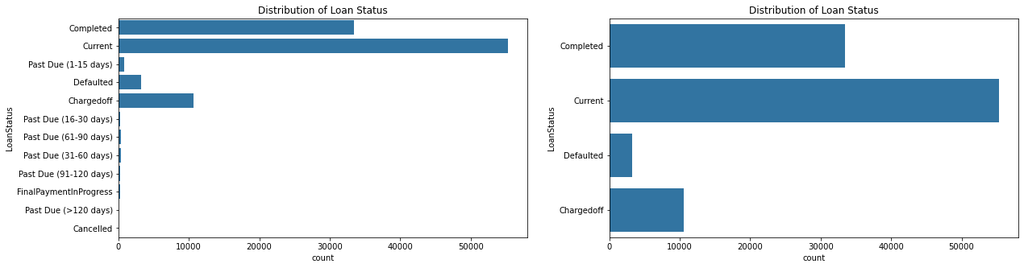

```python
plt.figure(figsize=[20, 5])
base_color = sb.color_palette()[0]

plt.subplot(1,2,1)
g = sb.countplot(y = 'LoanStatus', data = loan_dfc, color = base_color)
g.set(title = 'Distribution of Loan Status') ;

plt.subplot(1,2,2)
z = loan_dfc.loc[(loan_dfc.LoanStatus == 'Chargedoff') | (loan_dfc.LoanStatus == 'Completed') | (loan_dfc.LoanStatus == 'Current') | (loan_dfc.LoanStatus == 'Defaulted')]
g = sb.countplot(y = 'LoanStatus', data = z, color = base_color)
g.set(title = 'Distribution of Loan Status');
```

We can see the major categories are 'Completed', 'Current', 'Defaulted' and 'Chargedoff'.

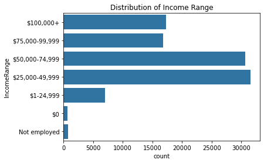

```python
plot_o = ['$100,000+', '$75,000-99,999', '$50,000-74,999', '$25,000-49,999', '$1-24,999', '$0', 'Not employed']
g = sb.countplot(y = 'IncomeRange', data = loan_dfc, color = base_color, order=plot_o)
g.set(title = 'Distribution of Income Range');
```

We can see that the 25,000 - 49,999 and the 50,000 - 74,999 are the 2 major income categories.

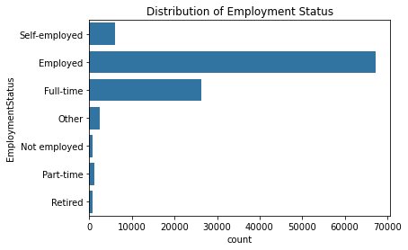

```python
g = sb.countplot(y = 'EmploymentStatus', data = loan_dfc, color = base_color)
g.set(title = 'Distribution of Employment Status');
```

We can see that majority are employed.

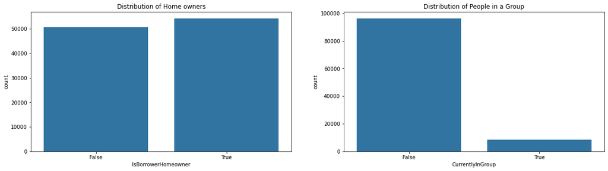

```python
plt.figure(figsize=[20, 5])

plt.subplot(1,2,1)
g = sb.countplot(x = 'IsBorrowerHomeowner', data = loan_dfc, color = base_color)
g.set(title = 'Distribution of Home owners');

plt.subplot(1,2,2)
g = sb.countplot(x = 'CurrentlyInGroup', data = loan_dfc, color = base_color)
g.set(title = 'Distribution of People in a Group');
```

We can see that there are lightly more home owners however, most borrowers are not in a group.

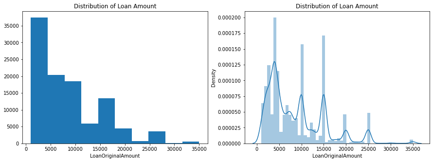

```python
plt.figure(figsize=[15,5])

plt.subplot(1,2,1)
plt.hist(x = 'LoanOriginalAmount', data = loan_dfc)
plt.xlabel('LoanOriginalAmount')
plt.title('Distribution of Loan Amount');

plt.subplot(1,2,2)
g = sb.distplot(loan_dfc['LoanOriginalAmount'])
g.set(title='Distribution of Loan Amount');
```

We can see that most loan requests are for 4,000 dollars, followed by 15,000 and 10,000 in that order.

```python
loan_O = loan_dfc.groupby('Occupation').size()
loan_O = loan_O.reset_index(name = 'counts')
df_o = loan_O.nlargest(10, 'counts')

df_o
```

|  | Occupation | counts |
| --- | --- | --- |
| 35 | Other | 27032 |
| 41 | Professional | 13019 |
| 12 | Computer Programmer | 4215 |
| 19 | Executive | 4148 |
| 59 | Teacher | 3613 |
| 1 | Administrative Assistant | 3506 |
| 2 | Analyst | 3442 |
| 47 | Sales - Commission | 3186 |
| 0 | Accountant/CPA | 3116 |
| 11 | Clerical | 2860 |

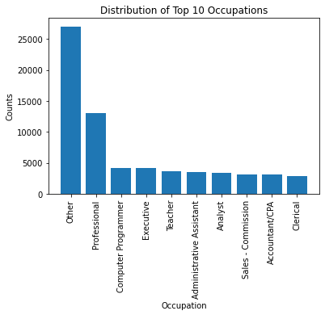

```python
x = df_o['Occupation']
y = df_o['counts']

plt.bar(x, y)
plt.xticks(rotation=90)
plt.xlabel('Occupation')
plt.ylabel('Counts')
plt.title('Distribution of Top 10 Occupations');
```

## Bivariate Exploration

```python
loan_dfc.head()
```

|  | LoanStatus | LoanOriginalAmount | BorrowerRate | Occupation | EmploymentStatus | EmploymentStatusDuration | IsBorrowerHomeowner | CurrentlyInGroup | IncomeRange | CreditScoreRangeLower | CreditScoreRangeUpper |
| --- | --- | --- | --- | --- | --- | --- | --- | --- | --- | --- | --- |
| 0 | Completed | 9425 | 0.1580 | Other | Self-employed | 2.0 | True | True | $25,000-49,999 | 640.0 | 659.0 |
| 1 | Current | 10000 | 0.0920 | Professional | Employed | 44.0 | False | False | $50,000-74,999 | 680.0 | 699.0 |
| 3 | Current | 10000 | 0.0974 | Skilled Labor | Employed | 113.0 | True | False | $25,000-49,999 | 800.0 | 819.0 |
| 4 | Current | 15000 | 0.2085 | Executive | Employed | 44.0 | True | False | $100,000+ | 680.0 | 699.0 |
| 5 | Current | 15000 | 0.1314 | Professional | Employed | 82.0 | True | False | $100,000+ | 740.0 | 759.0 |

```python
loandf_counts = z.groupby(['LoanStatus','IncomeRange']).size()
loandf_counts = loandf_counts.reset_index(name ='counts')
loandf_counts = loandf_counts.pivot(index = 'IncomeRange', columns= 'LoanStatus', values='counts')

loandf_counts
```

| LoanStatus IncomeRange | Chargedoff | Completed | Current | Defaulted |
| --- | --- | --- | --- | --- |
| $0 | 185 | 370 | 11 | 51 |
| $1-24,999 | 1328 | 2906 | 2277 | 334 |
| $100,000+ | 968 | 4773 | 10875 | 322 |
| $25,000-49,999 | 4161 | 10879 | 14528 | 1290 |
| $50,000-74,999 | 2633 | 9275 | 17286 | 873 |
| $75,000-99,999 | 1153 | 4914 | 10043 | 375 |
| Not employed | 182 | 324 | 248 | 25 |

```python
prop = loandf_counts.copy()
prop['Totals'] = prop.sum(axis=1)

prop['Chargedoff'] = prop['Chargedoff']/prop['Totals']
prop['Completed'] = prop['Completed']/prop['Totals']
prop['Current'] = prop['Current']/prop['Totals']
prop['Defaulted'] = prop['Defaulted']/prop['Totals']
prop.drop('Totals', axis = 1, inplace=True)
prop
```

| LoanStatus IncomeRange | Chargedoff | Completed | Current | Defaulted |
| --- | --- | --- | --- | --- |
| $0 | 0.299838 | 0.599676 | 0.017828 | 0.082658 |
| $1-24,999 | 0.194010 | 0.424543 | 0.332652 | 0.048795 |
| $100,000+ | 0.057150 | 0.281792 | 0.642047 | 0.019011 |
| $25,000-49,999 | 0.134843 | 0.352550 | 0.470802 | 0.041804 |
| $50,000-74,999 | 0.087571 | 0.308478 | 0.574916 | 0.029035 |
| $75,000-99,999 | 0.069942 | 0.298089 | 0.609221 | 0.022748 |
| Not employed | 0.233633 | 0.415918 | 0.318357 | 0.032092 |

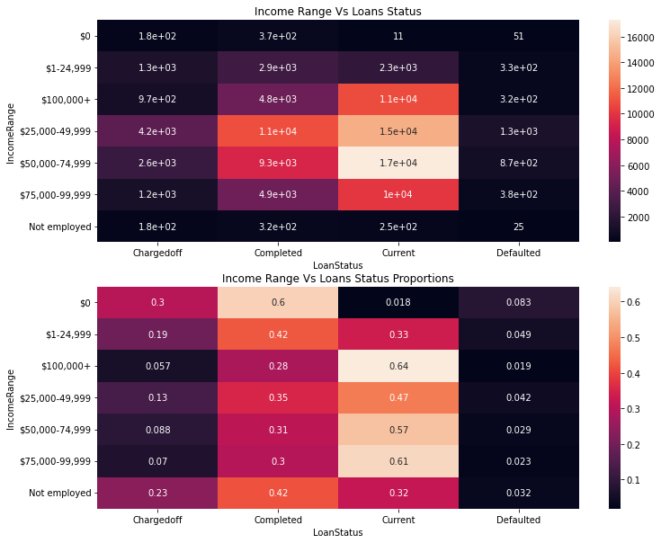

```python
plt.figure(figsize=[12,10])

plt.subplot(2,1,1)
g = sb.heatmap(loandf_counts, annot=True)
g.set(title = 'Income Range Vs Loans Status')

plt.subplot(2,1,2)
h = sb.heatmap(prop, annot=True)
h.set(title = 'Income Range Vs Loans Status Proportions');
```

The heat map shows a trend of high income range having a percentage of borrowers with current loans.

```python
e_status = z.groupby(['LoanStatus','EmploymentStatus']).size()
e_status = e_status.reset_index(name ='counts')
e_status = e_status.pivot(index = 'EmploymentStatus', columns= 'LoanStatus', values='counts')

e_status
```

| LoanStatus EmploymentStatus | Chargedoff | Completed | Current | Defaulted |
| --- | --- | --- | --- | --- |
| Employed | 3529 | 12332 | 48928 | 630 |
| Full-time | 5325 | 17326 | 1312 | 2200 |
| Not employed | 190 | 340 | 248 | 26 |
| Other | 295 | 436 | 1579 | 54 |
| Part-time | 198 | 786 | 24 | 58 |
| Retired | 180 | 458 | 92 | 58 |
| Self-employed | 893 | 1763 | 3085 | 244 |

```python
prop_e = e_status.copy()
prop_e['Totals'] = prop_e.sum(axis=1)

prop_e['Chargedoff'] = prop_e['Chargedoff']/prop_e['Totals']
prop_e['Completed'] = prop_e['Completed']/prop_e['Totals']
prop_e['Current'] = prop_e['Current']/prop_e['Totals']
prop_e['Defaulted'] = prop_e['Defaulted']/prop_e['Totals']
prop_e.drop('Totals', axis = 1, inplace=True)
prop_e
```

| LoanStatus EmploymentStatus | Chargedoff | Completed | Current | Defaulted |
| --- | --- | --- | --- | --- |
| Employed | 0.053945 | 0.188508 | 0.747917 | 0.009630 |
| Full-time | 0.203532 | 0.662233 | 0.050147 | 0.084088 |
| Not employed | 0.236318 | 0.422886 | 0.308458 | 0.032338 |
| Other | 0.124788 | 0.184433 | 0.667936 | 0.022843 |
| Part-time | 0.185741 | 0.737336 | 0.022514 | 0.054409 |
| Retired | 0.228426 | 0.581218 | 0.116751 | 0.073604 |
| Self-employed | 0.149206 | 0.294570 | 0.515455 | 0.040769 |

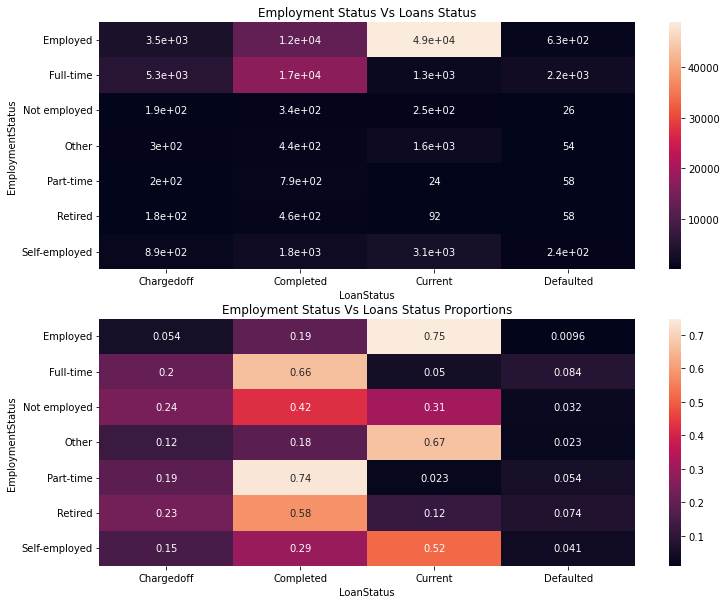

```python
plt.figure(figsize=[12,10])

plt.subplot(2,1,1)
g = sb.heatmap(e_status, annot=True)
g.set(title = 'Employment Status Vs Loans Status')

plt.subplot(2,1,2)
h = sb.heatmap(prop_e, annot=True)
h.set(title = 'Employment Status Vs Loans Status Proportions');
```

This shows that loans are mostly given to borrowers who are employed.

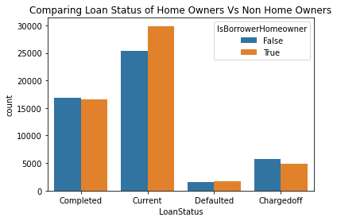

```python
g = sb.countplot(data = z, x = 'LoanStatus', hue = 'IsBorrowerHomeowner')
g.set(title = 'Comparing Loan Status of Home Owners Vs Non Home Owners');
```

This shows that with the current loans, more home owners were given loan compared to none home owners.

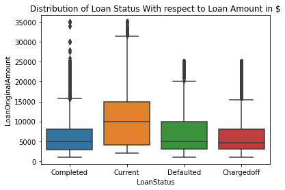

```python
g = sb.boxplot(data = z, x = 'LoanStatus', y = 'LoanOriginalAmount')
g.set(title ='Distribution of Loan Status With respect to Loan Amount in $');
```

This shows that most of the loans completed were about 15,000 dollars and below however, when compared with the current loans given, about 75% are 15,000 dollar or lower.

## Multivariate Exploration

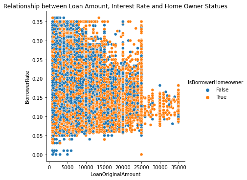

```python
g = sb.relplot(x = 'LoanOriginalAmount', y = 'BorrowerRate', data = z, hue = 'IsBorrowerHomeowner')
g.set(title = 'Relationship between Loan Amount, Interest Rate and Home Owner Statues');
```

This shows that rates on loans above 25,000 dollars fall below 0.2 and are mostly assessed by home owners.

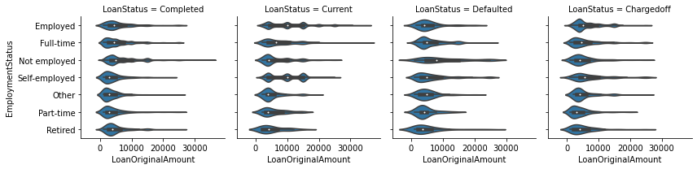

```python
g = sb.FacetGrid(data = z, col='LoanStatus')
g.map(sb.violinplot, 'LoanOriginalAmount', 'EmploymentStatus');
```

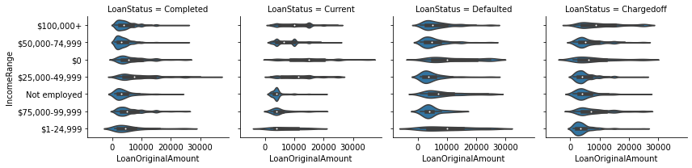

```python
g = sb.FacetGrid(data = z, col='LoanStatus')
g.map(sb.violinplot, 'LoanOriginalAmount', 'IncomeRange');
```

Looking at the income range, the 25,000 - 49,999 dollars range have the highest distribution on completed loan payments.

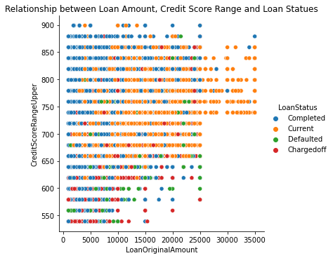

```python
g = sb.relplot(x = 'LoanOriginalAmount', y = 'CreditScoreRangeUpper', data = z, hue = 'LoanStatus')
g.set(title = 'Relationship between Loan Amount, Credit Score Range and Loan Statues');
```

We see here that loans above 25,000 dollars are only assesed by credit scores above 740 and are mostly current loans.

## Conclusions

> It can be observed from these visualizations that current loans and loans above 25,000 dollars are given to borrowers with the most favorable characteristics to complete the loans like, higher income range, higher credit scores and home owners.